# Raport

Karolina Sławińska, Małgorzata Filipiak

2026-06-05

## Wprowadzenie i Opis Danych:

Niniejszy raport powstał w celu przekształcenia surowych danych sprzedażowych w strategiczne wnioski biznesowe. Analiza opiera się na dużym, publicznie dostępnym zbiorze danych pobranym z platformy Kaggle, dotyczącym ekwadorskiej sieci supermarketów Corporación Favorita.

**Charakterystyka analizowanego zbioru danych:**

- **Zakres czasowy:** Dane obejmują codzienne transakcje rejestrowane w latach 2013–2017.
- **Kluczowe zmienne:** Zbiór zawiera informacje o dacie transakcji (`date`), numerze identyfikacyjnym placówki (`store_nbr`), kategorii asortymentowej (`family` – np. napoje, artykuły spożywcze, kosmetyki), wolumenie sprzedaży (`sales`) oraz liczbie produktów danego typu objętych w danym dniu promocją (`onpromotion`).
- **Cel analizy:** Wykorzystanie dedykowanego pakietu `salesanalystR` do identyfikacji długoterminowych trendów, oceny realnego wpływu rabatów na decyzje zakupowe klientów, stworzenia rankingu najbardziej efektywnych sklepów oraz przetestowania zaawansowanych modeli prognostycznych (ARIMA i Prophet) w celu przewidzenia popytu na kolejne 30 dni.

## 1. Trendy sprzedażowe produktów (POZIOM 2)

Analiza historycznych szeregów czasowych pozwala na identyfikację głównych wzorców zachowań konsumentów.

Poniższy wykres prezentuje ogólny trend sprzedaży produktów w analizowanym okresie. Widoczne fluktuacje mogą wynikać z naturalnej sezonowości tygodniowej lub rocznej.

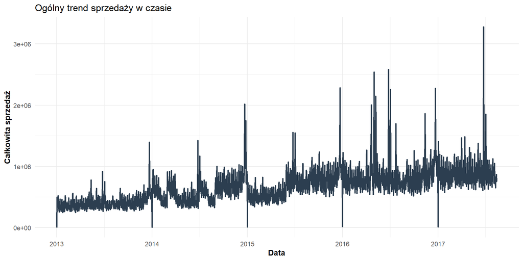

**Rekomendacje dla biznesu:** Zarządzanie łańcuchem dostaw musi zostać zoptymalizowane pod kątem końcówki roku - sieć musi być gotowa na obsłużenie ponad dwukrotnie większego ruchu.

## 2. Skuteczność promocji (POZIOM 2)

Top 10 kategorii o najwyższej sprzedaży oraz ich wsparcie promocyjne

| Kategoria | Całkowita Sprzedaż | Średni Udział Promocji (%) |
| --- | --- | --- |
| GROCERY I | 350 827 298 | 62.56 |
| BEVERAGES | 221 663 540 | 56.86 |
| PRODUCE | 125 447 968 | 33.85 |
| CLEANING | 99 421 019 | 54.87 |
| DAIRY | 65 823 605 | 50.57 |
| BREAD/BAKERY | 42 959 924 | 42.77 |
| POULTRY | 32 494 451 | 21.67 |
| MEATS | 31 650 996 | 23.61 |
| PERSONAL CARE | 25 100 482 | 42.04 |
| DELI | 24 585 627 | 43.41 |

**WNIOSKI ANALITYCZNE DOTYCZĄCE SKUTECZNOŚCI PROMOCJI:**

## 3. Prognozowanie sprzedaży (POZIOM 3)

Kluczowym elementem analizy szeregów czasowych jest predykcja przyszłego popytu. Wykorzystanie modeli prognostycznych pozwala firmie na optymalizację łańcucha dostaw, zmniejszenie kosztów magazynowania oraz lepsze przygotowanie się na nadchodzące piki sprzedażowe.

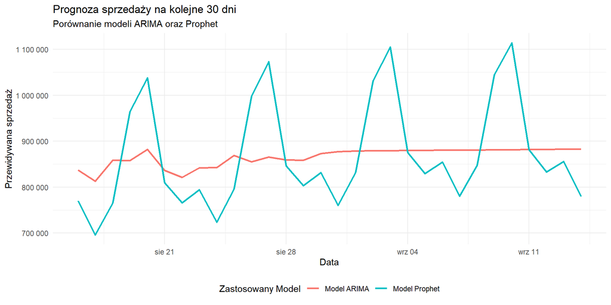

**Wnioski analityczne i ocena modeli:**

Analiza wygenerowanej prognozy na kolejne 30 dni (od połowy sierpnia do połowy września) ujawnia różnice w sposobie przewidywania popytu przez zastosowane algorytmy:

- **Spłaszczenie trendu w modelu ARIMA:** Tradycyjny model ARIMA (czerwona linia) wygenerował bardzo zachowawczą prognozę. Po początkowych, niewielkich wahaniach na poziomie 810–850 tysięcy, linia trendu ulega szybkiej stabilizacji i niemal całkowicie wypłaszcza się w okolicach 880 tysięcy. Oznacza to, że algorytm uchwycił ogólny średni wolumen, ale nie poradził sobie z mapowaniem lokalnej zmienności.
- **Wysoka czułość modelu Prophet:** Algorytm Prophet (niebieska linia) doskonale zidentyfikował i odwzorował silną, powtarzalną sezonowość tygodniową sieci. Wskazuje on na regularne, głębokie spadki sprzedaży (w okolicach 700–750 tysięcy) przeplatane ostrymi, powtarzającymi się pikami, w których sprzedaż gwałtownie przekracza próg 1 miliona sztuk (osiągając w szczytach nawet 1,1 mln).

**Rekomendacja dla łańcucha dostaw:** Do celów bieżącego zarządzania zaopatrzeniem i planowania grafików pracowniczych należy bezwzględnie wykorzystywać prognozy z modelu Prophet. Zastosowanie spłaszczonych wyliczeń z modelu ARIMA (ok. 880 tys. dziennie) doprowadziłoby do braków towarowych (out-of-stock) w dni szczytowe oraz zalegania produktów na magazynie w dniach o niższym popycie.

## 4. Porównanie sklepów i kategorii (POZIOM 3)

W celu optymalizacji działań handlowych, niezbędne jest zrozumienie dysproporcji sprzedażowych pomiędzy poszczególnymi placówkami oraz kategoriami. Poniższa analiza wykorzystuje logikę biznesową pakietu do zestawienia wyników:

Ranking Top 10 Sklepów generujących największy obrót

| Numer Sklepu | Całkowita Sprzedaż | Ilość Akcji Promocyjnych |
| --- | --- | --- |
| 44 | 63 356 137 | 192 449 |
| 45 | 55 689 022 | 191 503 |
| 47 | 52 024 476 | 192 725 |
| 3 | 51 533 528 | 177 075 |
| 49 | 44 346 823 | 184 736 |
| 46 | 42 804 727 | 190 697 |
| 48 | 36 741 804 | 185 566 |
| 51 | 33 603 861 | 162 576 |
| 8 | 31 124 067 | 169 671 |
| 50 | 29 273 751 | 174 115 |

**WNIOSKI ANALITYCZNE:**

Analiza zestawienia TOP 10 najlepszych placówek sieci ujawnia kluczowe mechanizmy wpływające na obroty:

- **Dominacja lidera:** Sklep nr 44 bezapelacyjnie wygrywa ranking (ponad 63 mln obrotu), generując ponad dwukrotnie większą sprzedaż niż placówka zamykająca pierwszą dziesiątkę.
- **Siła promocji:** Najlepsze wyniki są ściśle powiązane z agresywną polityką rabatową. Trzy najlepsze sklepy przeprowadziły po ponad 190 tysięcy akcji promocyjnych w badanym okresie.
- **Wyjątek od reguły (Sklep nr 3):** Sklep nr 3 osiąga świetne wyniki (51 mln) przy odczuwalnie mniejszej liczbie promocji, co świadczy o wybitnej sprzedaży organicznej (bez rabatów) i lojalnej bazie klientów.

**Rekomendacje biznesowe:** Dział optymalizacji sprzedaży powinien zbadać praktyki Sklepu nr 3 i wdrożyć je w placówkach takich jak Sklep nr 46, które obecnie generują słabsze wyniki finansowe mimo ogromnych nakładów na promocje.